# Cartography, Spatial Analysis & Reproducible Research with R

January 2016

## Presentation Outline

- What is R?
- Cartography
- Spatial Analysis
- Reproducible Research

## What is R?

## What is R?

- R is a language and environment that provides a wide variety of statistical and graphical techniques, and is highly extensible.
- R is available as Free Software under the terms of GNU General Public License.
- R is cross-platform (GNU/Linux, Windows, OS X).

[r-project website](https://www.r-project.org/about.html)

## R Popularity and Vitality

- 119 254 R questions on [StackOverflow](https://stackoverflow.com/questions/tagged/r)
- 7 727 [user-contributed packages](https://cran.rstudio.com/)
- Preferred language of self-proclaimed data scientists on [LinkedIn](http://blog.revolutionanalytics.com/2015/11/new-surveys-show-continued-popularity-of-r.html)
- Among top languages on [GitHub](http://githut.info/)
- Five updates in 2015
- 174 [Local R User Groups](http://blog.revolutionanalytics.com/local-r-groups.html), 2 in Greece ([Patras](http://www.meetup.com/Patras-R-Users-Group) & [Athens](http://www.meetup.com/AthensR/))

## R Popularity and Vitality

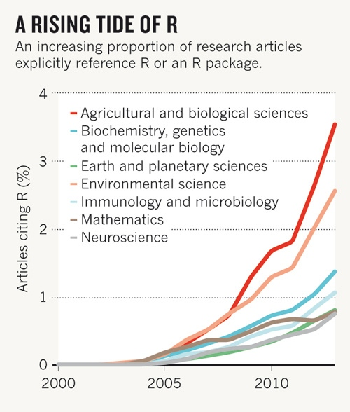

Sylvia Tippmann/Source: Elsevier Scopus database

## R Environment

- R Base: [R](https://www.r-project.org/)
- User-contributed Packages: [The Comprehensive R Archive Network](http://cran.cc.uoc.gr/mirrors/CRAN/)
- Integrated Development Environment (IDE): [RStudio](https://www.rstudio.com/)

## R Usage

A look at RStudio and some basic examples of code…

basic_examples.R

## Cartography

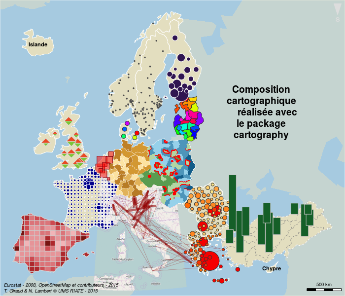

## Spatial Data Handling

Two fundamental packages:

- `sp`: handle and display of spatial objects
- `rgdal`: import/export spatial objects, manage cartographic projections

spatial_data_handling.R

## Thematic cartography

The `cartography` package allows various **cartographic representations** and some additional features:

- Proportional symbols maps
- Chroropleth maps
- Typology maps
- Flow maps
- Discontinuities maps
- Cartographic palettes
- Layout
- Nice legends
- Access to cartographic API
- Irregular polygons to regular grid transformation with data handling

## Thematic cartography

Basic examples…

basic_examples_cartography.R

## Thematic cartography

More customized examples in the package vignette.

Access to the vignette in R:

```r
vignette(topic = "cartography")
```

Access to the vignette on the web:  
[Commented Scripts to Build Maps with cartography](https://cran.r-project.org/web/packages/cartography/vignettes/cartography.html)

## Interactive Maps

With the `leaflet` package

```r
library(leaflet)
# initialize a map
m <- leaflet(width = 700, height = 500)
# add a basemap
m <- addTiles(map = m)
# center on a localization
m <- setView(map = m, lng = 21.182957, lat = 39.771098, zoom = 15)
# add a pop-up
m <- addPopups(map = m, lng = 21.182957, lat = 39.771098,
               popup = '<a href="https://el.wikipedia.org/wiki/%CE%9C%CE%AD%CF%84%CF%83%CE%BF%CE%B2%CE%BF">
               Μέτσοβο                       </a><br/><br/>
               <img src="https://upload.wikimedia.org/wikipedia/en/8/80/Wikipedia-logo-v2.svg"/>')
# affichage de la carte
m
```

## Interactive Maps

[interactive chart not shown]

## Interactive Maps

[figure not shown]

## Spatial Analysis

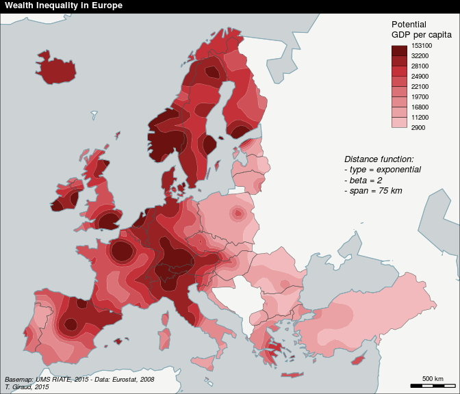

## Geoprocessing

One fundamental package:  
The `rgeos` package gives access to the GEOS ([Geometry Engine - Open Source](http://trac.osgeo.org/geos/)) library.

- Area / Perimeter
- Distances
- Buffer
- Overlap / intersect / difference
- Contains / within
- Union
- …

## Distance calculation

Euclidean distance vs. Road distance

distance.R

## Basic Point Pattern Analysis

An example of (very) basic point pattern analysis of geocoded tweets.

tweets.R

## Discontinuities

How to extracts discontinuities (borders) between regions.

disc.R

## Spatial Smoothing

The `SpatialPosition` package allow to compute Stewart potentials (gravitational potential) \[ A_i = \sum_{j=1}^n O_j f(d_{ij}) \]

- \(A_i\) potentiel en \(i\)
- \(O_j\) stock de population sur \(j\)
- \(f(d_{ij})\) fonction négative de la distance entre \(i\) et \(j\)

smooth.R

## Reproducible Research

## Reproducible Research

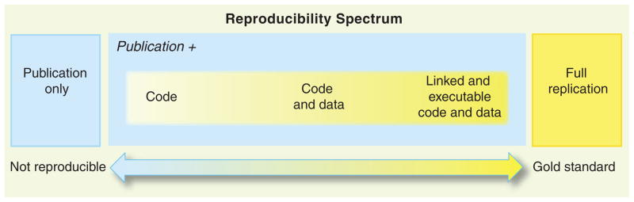

Roger D. Peng - 2011

## Reproducible Research

The ability to communicate complete analyses by providing the script that reruns the analysis.

*"The R Software Environment is a good choice to carry out reproducible geoscientific research. The main argument is that the combination of (i) being a free, open source, cross-platform environment with clear software provenance, versioning and archiving with (ii) maintaining open, documented, accessible and sustained communication channels between users and developers, creates trust by individuals and organisations."* **Bivand et al - 2013**

## Dynamic Report Generation

[Markdown](https://daringfireball.net/projects/markdown/), an easy-to-read and easy-to-write markup language.

greece_2016_with_code.Rmd

## This Presentation!

This presentation has been written in rMarkdown and build within RStudio.  
greece_2016.Rmd

## Resources

## Resources

- [R-sig-Geo Mailing list](https://stat.ethz.ch/mailman/listinfo/r-sig-geo) *R Special Interest Group on using Geographical data and Mapping*
- [CRAN Task View: Analysis of Spatial Data](https://cran.r-project.org/web/views/Spatial.html)
- [R-bloggers](http://www.r-bloggers.com/) *A blog aggregator of content collected from bloggers who write about R (in English).*
- [Applied Spatial Data Analysis with R](http://link.springer.com/book/10.1007/978-1-4614-7618-4) (Roger S. Bivand, Edzer Pebesma, Virgilio Gómez-Rubio)
- [Tips for reading spatial files into R with rgdal](http://zevross.com/blog/2016/01/13/tips-for-reading-spatial-files-into-r-with-rgdal/)
- **A lot of tutorials and presentations online**

## ευχαριστώ !

## ευχαριστώ !

timothee.giraud@ums-riate.fr

GitHub: https://github.com/rCarto/

Blog: http://rgeomatic.hypotheses.org/